# Text preprocessing and visualization

Jack Lovell

9/16/2020

# Intro

So let’s get to it!

We will check out comp neuro twitter

```r
#Import rtweet and other libs
library(rtweet)
library(dplyr)
```

```r
# plotting and pipes - tidyverse!
library("ggplot2")
library(dplyr)
# text mining library
library(tidytext)
# plotting packages
library(igraph)
library(ggraph)
#Use our own token
twitter_token <- create_token(
  app = 'meta_nlp',
  consumer_key="pzOo1DHoCGpIjElgpHzVDHgl4",
  consumer_secret="QpTDNngQEDv9CkroVTjBlpRQcoL4iJvGkrAqPNAmXrIFdEVSNE",
  access_token="1301874142359293952-K7O1mzxSh7PEPR799S9Db3cfHzLx97",
  access_secret="mOvMMSEmBGZwT9sqZzuX8Oe1K2PRFwohGEOA6KEkxXZ1w"
)
#search twitter
science_tweets <- search_tweets(q="computational+neuroscience", n = 50000, lang="en", include_rts = F)
head(science_tweets$text)
```

```
## [1] "#superneuromatch abstract submission deadline is October 2! (Yes, that fast!). *ALL NEUROSCIENCE AREAS COVERED* computational, developmental, social, clinical, cellular/molecular, motor, sensory, education, ethics, animal, human, you name it!\nSubmit now at https://t.co/Kod7ymVlxj"
## [2] "taking a neuroscience course so that I can take computational neuro and my math brain can’t handle these dissections pls just show me data"
## [3] "New Research: Braitenberg Vehicles as Computational Tools for Research in Neuroscience: Valentino Braitenberg reported his seminal thought experiment in 1984 using reactive automatons or vehicles with relatively simple… https://t.co/dvTPI4d4uN #bioengineering #biotech"
## [4] "The scientific study of the nervous system increased significantly during the second half of the twentieth century, principally due to advances in molecular biology, electrophysiology, and computational neuroscience.\n#neurobiology #nervoussystem #neuroscience #openaccess"
## [5] "Applications are open (until 29Sep) for a research fellowship in the Neuroengineering and Computational Neuroscience group at #i3S. Profile \U0001f447 \nFull announcement: https://t.co/xgvgQ1VbJ4\n#i3Sjobs"
## [6] "Biological Cybernetics journal has a new subtitle, \"Advances in Computational Neuroscience and in Control and Information theory for Biological Systems” and a broader aims and scope https://t.co/sHYWFvgp6G #biocybernetics https://t.co/1vX0bl6VAx"
```

# Preprocessing text

Our first step will be removing URLS from our tweets, as those are clearly not useful in a text analysis!

```r
#lets do this manually & without the tidyverse package
science_tweets$stripped_text <- gsub("http.*","",  science_tweets$text)
science_tweets$stripped_text <- gsub("https.*","", science_tweets$stripped_text)
head(science_tweets$stripped_text)
```

```
## [1] "#superneuromatch abstract submission deadline is October 2! (Yes, that fast!). *ALL NEUROSCIENCE AREAS COVERED* computational, developmental, social, clinical, cellular/molecular, motor, sensory, education, ethics, animal, human, you name it!\nSubmit now at "
## [2] "taking a neuroscience course so that I can take computational neuro and my math brain can’t handle these dissections pls just show me data"
## [3] "New Research: Braitenberg Vehicles as Computational Tools for Research in Neuroscience: Valentino Braitenberg reported his seminal thought experiment in 1984 using reactive automatons or vehicles with relatively simple… "
## [4] "The scientific study of the nervous system increased significantly during the second half of the twentieth century, principally due to advances in molecular biology, electrophysiology, and computational neuroscience.\n#neurobiology #nervoussystem #neuroscience #openaccess"
## [5] "Applications are open (until 29Sep) for a research fellowship in the Neuroengineering and Computational Neuroscience group at #i3S. Profile \U0001f447 \nFull announcement: "
## [6] "Biological Cybernetics journal has a new subtitle, \"Advances in Computational Neuroscience and in Control and Information theory for Biological Systems” and a broader aims and scope "
```

Nice! We now have a new column called ‘stripped_text’ too which is great, as our original data are not tampered with at all.

Rather than going through each step of cleaning the text like we did last time (i.e. convert to lowercase, remove punctuation, etc.) we can leverage the power of the tidytext and use the function unset_tokens(). Which is super useful in speeding up your precprocessing pipeline. Just make sure you know what it is doing!!

```r
#lets store it in a new column!
science_tweets_clean <- science_tweets%>%
  dplyr::select(stripped_text)%>%
  tidytext::unnest_tokens(word, stripped_text)
```

Now let’s visualize this data, as it give us a better understanding of what is really going on in our data.

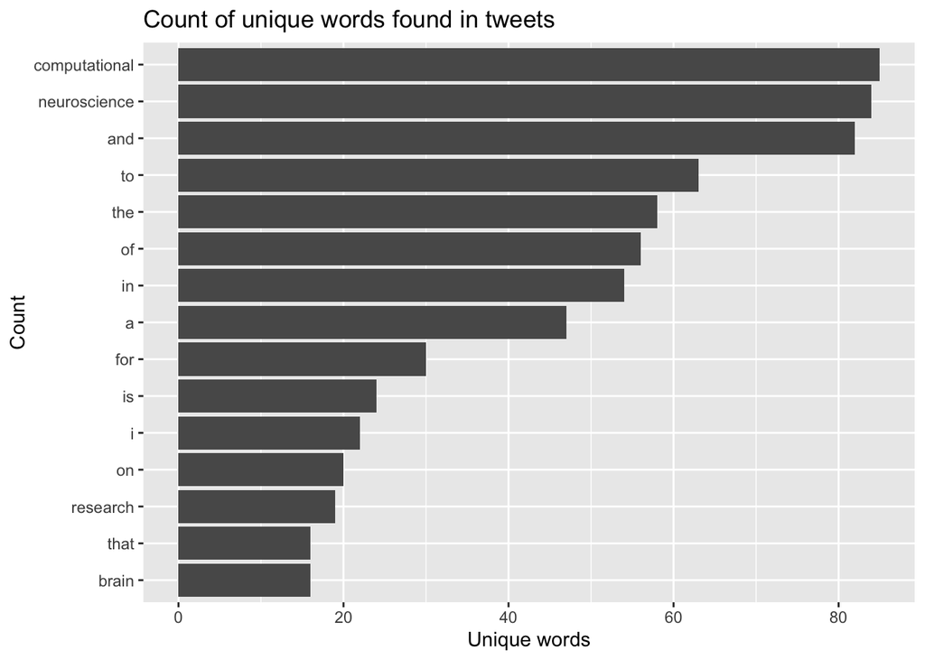

```r
# plot the top 15 words -- notice any issues?
science_tweets_clean %>%
  count(word, sort = TRUE) %>%
  top_n(15) %>%
  mutate(word = reorder(word, n)) %>%
  ggplot(aes(x = word, y = n)) +
  geom_col() +
  xlab(NULL) +
  coord_flip() +
      labs(x = "Count",
      y = "Unique words",
      title = "Count of unique words found in tweets")
```

## Stop words

As we saw last time, we don’t want “stop words” as they give don’t contribute to the smenatic meaning of the text at all… After plotting the number of unique words, it is obvious that some of the most frequent words are ‘stop words.’ Let’s leverage the power of tidytext and remove these! We can do this by using the stop_words data, and anti_join() to remove them.

```r
data("stop_words")
#what is it?
head(stop_words)
```

| word | lexicon |
| --- | --- |
| a | SMART |
| a's | SMART |
| able | SMART |
| about | SMART |
| above | SMART |
| according | SMART |

```r
#how many rows w/ stop words
nrow(science_tweets_clean)
```

```
## [1] 2288
```

```r
#remove
cleaned_tweet_words <- science_tweets_clean%>%
  anti_join(stop_words)
#now how many rows?
nrow(cleaned_tweet_words)
```

```
## [1] 1269
```

Wow, our data were nearly halfed. Let’s take another look at the data now that it’s a bit more clean

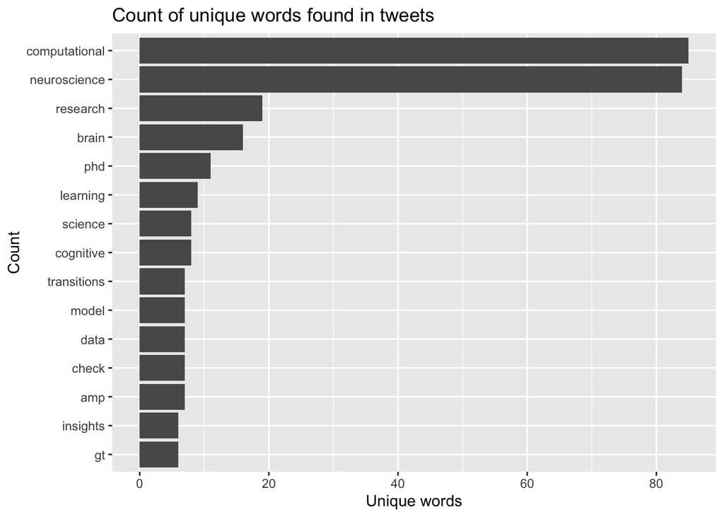

```r
# plot the top 15 words
cleaned_tweet_words %>%
  count(word, sort = TRUE) %>%
  top_n(15) %>%
  mutate(word = reorder(word, n)) %>%
  ggplot(aes(x = word, y = n)) +
  geom_col() +
  xlab(NULL) +
  coord_flip() +
      labs(x = "Count",
      y = "Unique words",
      title = "Count of unique words found in tweets")
```

Nice, so now it’s a bit more obvious what our tweets are saying. Rather than trying to nterpret what people were saying with the word “and”, we can test meaningful differences in our data, such as if cognitive or biology was mentioned more. Or what topics of interest were mentioned most (emotion, gene transcription, etc.)

# Bigrams

One piece of insight that would be good to gain is to see what words occur with eachother. Some call this looking for “networks” of words, and i often known as searching for “bigrams” within your data. This will be an important concept when we get to modeling, but for now all we will need to know is that it is telling us which words are said in succession.

```r
library(devtools)
install_github("dgrtwo/widyr")
```

```
## Skipping install of 'widyr' from a github remote, the SHA1 (13b3b3c4) has not changed since last install.
##   Use `force = TRUE` to force installation
```

```r
library(widyr)

# remove punctuation, convert to lowercase, add id for each tweet!
science_tweets_paired_words <- science_tweets %>%
  dplyr::select(stripped_text) %>%
  unnest_tokens(paired_words, stripped_text, token = "ngrams", n = 2)

science_tweets_paired_words %>%
  count(paired_words, sort = TRUE)
```

| paired_words | n |
| --- | --- |
| computational neuroscience | 55 |
| in computational | 11 |
| neuroscience and | 9 |
| of the | 9 |
| in the | 7 |
| and computational | 6 |
| and transitions | 6 |
| brain states | 6 |
| from computational | 6 |
| insights from | 6 |

[output cut: 1918 more lines]

```r
library(tidyr)
science_tweets_separated_words <- science_tweets_paired_words %>%
  separate(paired_words, c("word1", "word2"), sep = " ")

science_tweets_filtered <- science_tweets_separated_words %>%
  filter(!word1 %in% stop_words$word) %>%
  filter(!word2 %in% stop_words$word)

# new bigram counts:
science_words_counts <- science_tweets_filtered %>%
  count(word1, word2, sort = TRUE)

head(science_words_counts)
```

| word1 | word2 | n |
| --- | --- | --- |
| computational | neuroscience | 55 |
| transitions | insights | 6 |
| cognitive | neuroscience | 5 |
| cell | reports | 4 |
| computational | cognitive | 4 |
| phd | candidate | 4 |

Now let’s visualize our network

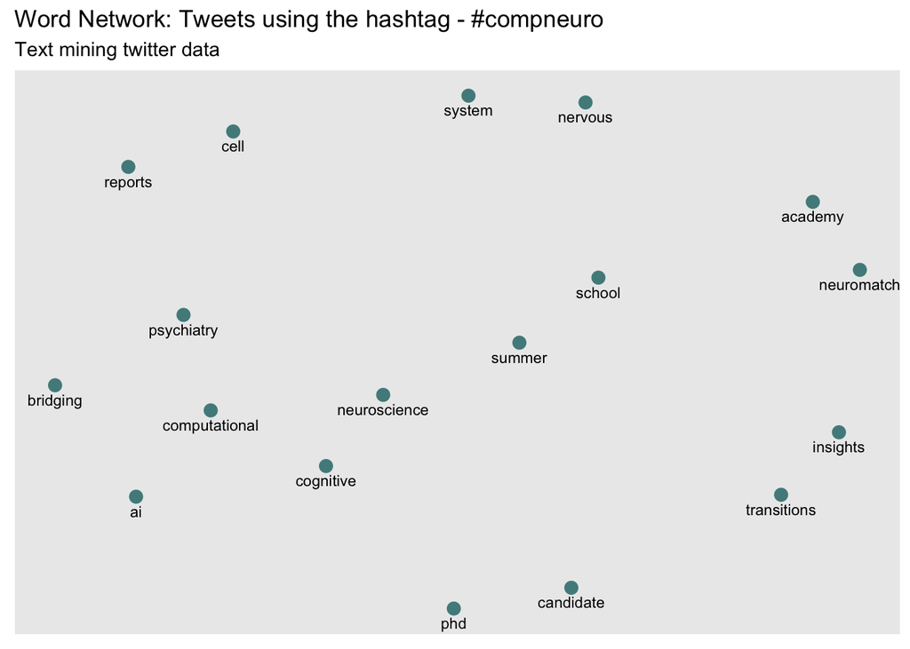

```r
library(igraph)
library(ggraph)

# plot comp neuro word network
# (plotting graph edges is currently broken)
science_words_counts %>%
        filter(n >= 3) %>%
        graph_from_data_frame() %>%
        ggraph(layout = "fr") +
        # geom_edge_link(aes(edge_alpha = n, edge_width = n))
        # geom_edge_link(aes(edge_alpha = n, edge_width = n)) +
        geom_node_point(color = "darkslategray4", size = 3) +
        geom_node_text(aes(label = name), vjust = 1.8, size = 3) +
        labs(title = "Word Network: Tweets using the hashtag - #compneuro",
             subtitle = "Text mining twitter data ",
             x = "", y = "")
```